# Vignette for geneSetSimplifyR

Kristoffer Vitting-Seerup & Lars Rønn Olsen

14 June, 2023

# Background and Rational

Gene-set enrichment analysis (GSEA) is one of the most useful types of bioinformatic analysis since it summarizes long list of genes (e.g. TP53, CD1) into more high-level biological concepts (e.g. “cell cycle”, “DNA repair”). While GSEA are potentially extremely powerful for profiling the high-level biological changes in a system this is often hampered by very long list of significant gene sets. This point is demonstrated by our [recent article](https://www.biorxiv.org/content/10.1101/2022.08.29.505720v3) where we re-analyze 100 RNA-seq data sets and show the average average dataset had 1700+ gene sets significantly enriched among differentially expressed genes.

It is naturally not possible to manually analyze such long list so in practice scientics often just show the most significant/enriched gene-sets or cherry pick gene-sets based on prior biological hypothesis. Neither is naturally desirable (or good scientific practice?) hence approaches to analyzing such long list of gene sets are neeeded.

That is why we created `geneSetSimplifyR`. `geneSetSimplifyR` solves this problem by:

- Group gene-sets into a small number of highly redundant/overlapping clusters througth unsupervised clustering
- Intelligently assign labels to each cluster making it easy to figure out the core biology behind a cluster
- Provide a host of intuitive plots enable both visualization and exploation of these clusters

`geneSetSimplifyR` works on the output from *any* gene-set enrichment analysis tool but work especially well with [fgsea](https://bioconductor.org/packages/fgsea/).

# Installation

`geneSetSimplifyR` can be installed from github by copy pasting this command into R:

```r
if (!requireNamespace("devtools", quietly = TRUE)){
  install.packages("devtools")
}
devtools::install_github("kvittingseerup/geneSetSimplifyR", build_vignettes = TRUE)
```

# geneSetSimplifyR workflow

## Overview

`geneSetSimplifyR` works on the output from *any* gene-set enrichment analysis tool but work especially well with [fgsea](https://bioconductor.org/packages/fgsea/).

The input to `geneSetSimplifyR` is simply:

- A list of the gene-sets that should be clustered
- Optionally(!) meta data about the enrichment analysis that can be used for downstream visualization. Specifically `geneSetSimplifyR` support visualization of
- enrichment scores for each gene-set (e.g. NES, odds ratio, etc)
- multi-conditional data (joint comparison of several analysis each finding gene-sets of interest).

1. Cluster and label gene-sets
2. Visual exploration of the gene-set clustering
3. Exploring and verifying clusters

Each part will be elaborated on in separate sections below

## Cluster and label gene-sets

We start by loading the `geneSetSimplifyR` library and it’s associated example data

```r
library(geneSetSimplifyR)

data("exampleGeneSets")
data("exampleEnrichment")
```

Lets expore the data to see what should look like

```r
### The gene sets are a list
class(exampleGeneSets)
```

```
#> [1] "list"
```

```r
### Where each entry is a gene set and its annoated genes
str(head(exampleGeneSets,2))
```

```
#> List of 2
#>  $ GOBERT_OLIGODENDROCYTE_DIFFERENTIATION_UP: chr [1:498] "AAAS" "ABCB1" "ADAM23" "AEN" ...
#>  $ FISCHER_DREAM_TARGETS                    : chr [1:819] "AAAS" "ABCB10" "ABCE1" "ABHD10" ...
```

```r
### The optional data have both enrichment_score and source
head( exampleEnrichment, 2 )
```

```
#> # A tibble: 2 × 3
#>   source     pathway                          enrichment_score
#>   <chr>      <chr>                                       <dbl>
#> 1 Expression GRADE_COLON_AND_RECTAL_CANCER_UP             1.22
#> 2 Splicing   BENPORATH_NANOG_TARGETS                      1.12
```

With the data read we are now ready to use `geneSetSimplifyR`. The main functionalities are:

- Clusters gene-sets based on the overlap in genes annotated to the gene-sets
- Intelligently labels the clusters from the most informative words in the gene-set name

All functionality is wrapped into the *geneSetSimplifyR()* function:

```r
exampleGsList <- geneSetSimplifyR(
  geneSetsList = exampleGeneSets,
  geneSetsDF = exampleEnrichment,
  resolution = c(0.1, 0.6, 1.1, 1.6), # for quick run - delete when running on real data
  verbose = FALSE
)

exampleGsList
```

```
#> [1] "A gsList object with 204 gene sets from 2 source(s) clustered into 4 labeled clusters."
```

Please note that:

1. While the visualizations in `geneSetSimplifyR` have a deep integration with the enrichment scores and source annotation these are neither needed or used for the clustering/labeling therefore *geneSetsDF* argument is optional.
2. The *resolution* argument is the hyper-parameter that controls the “level” of clustering with higher values typically resulting in smaller values.
3. Here we only use a few small *resolution* for very quick run on the example data. In practice we recommend using a large range of resolutions as
- These can be utilized and explored downstream
- `geneSetSimplifyR` automatically picks the optimal *resolution* from the once tested - here resulting i 4 clusters

The optimal *resolution* was determined to be 1.1 as shown by:

```r
extractResolution(exampleGsList)
```

```
#> [1] 1.1
```

## Visual exploration of the gene-set clustering

Now with the clustering and labeling done we are ready to explore the data visually. If you did not run the code above to generate the example dataset you can load the example gsList as follows:

```r
data("exampleGsList")
exampleGsList
```

```
#> [1] "A gsList object with 204 gene sets from 2 source(s) clustered into 4 labeled clusters."
```

To get an overview of the clusters the simplest visualization is a bar chart.

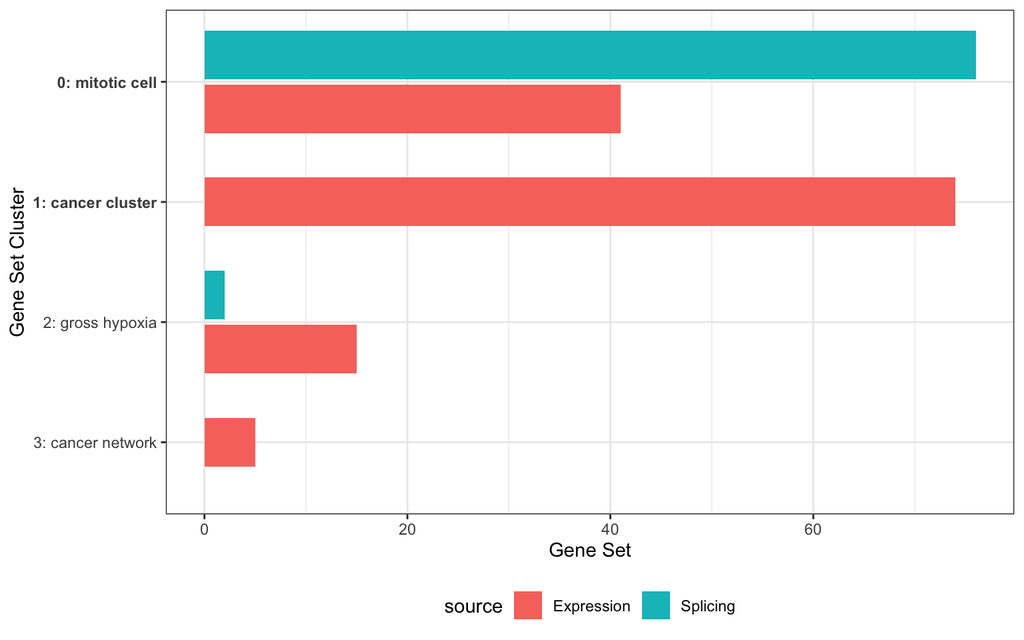

```r
plotBarchart(
  geneSetsList = exampleGsList,
  highligthClusterNo = c(0,1)
)
```

Showing we have 4 clusters with “mitotic cell” and “cancer cluster” being the largest. We also immediately see that the “mitotic cell” cluster is to a large extend (primarly?) driven by splicing gene sets while the “cancer cluster” is exclusively driven by expression associated gene-sets. This naturally suggest lot of genes involved in cell cycle are affected by splicing.

Also note that the `highligthClusterNo` is available for most plotting function maiking it easy to visualy communicate which clusters you think are most interesting.

We can also visualize the gene-sets cluster in an UMAP plot:

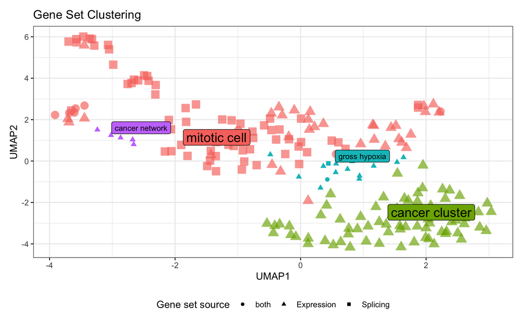

```r
plotUMAP(
  geneSetsList = exampleGsList,
  highligthClusterNo = c(0,1),
  removeClusterId = TRUE,
  pointAlpha = 1 # because there are relatively few gene-sets here
)
```

Which automatically plots the source as the shape. The UMAP plot function has many arguments enabling fine-tuning the plot. Here we just want to highlight the use of `removeClusterId`. While the cluster numbers are useful for quick referral to clusters (important later) it is often desirable to remove. Hence the `removeClusterId` argument (implemented in all plot functions) remove the cluster number (e.g. “1:” of the “1: cancer cluster”).

We already mentioned how we see differences in cluster composition. This can naturally also be directly visualized:

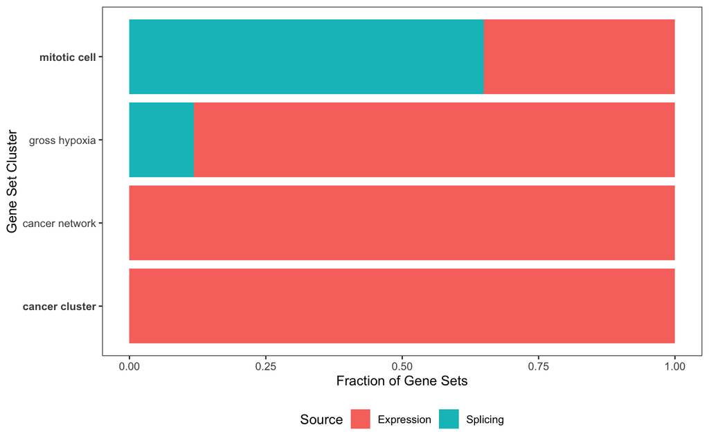

```r
plotProportions(
  geneSetsList = exampleGsList,
  highligthClusterNo = c(0,1),
  removeClusterId = TRUE
)
```

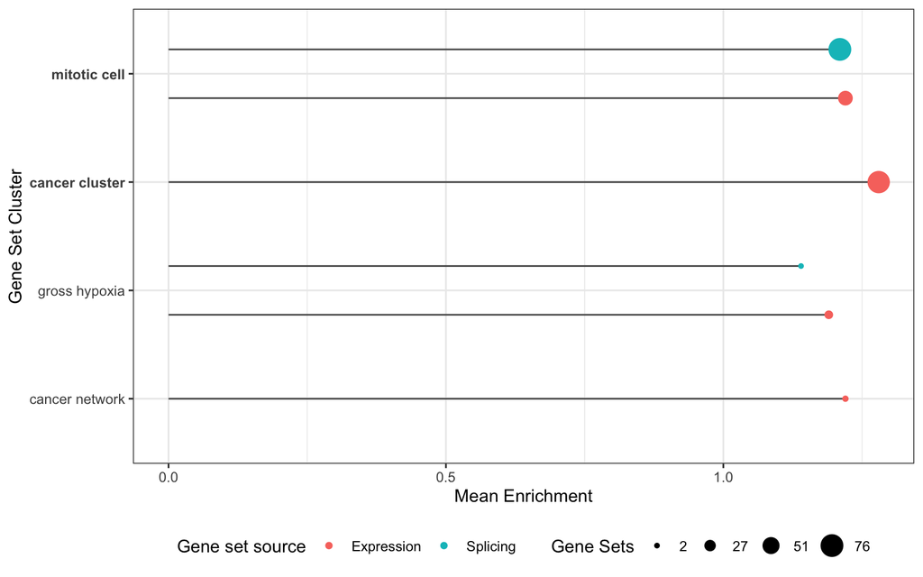

```r
plotEnrichment(
  geneSetsList = exampleGsList,
  highligthClusterNo = c(0,1),
  removeClusterId = TRUE
)
```

But we can also visualize all enrichment scores in a violin plot

```
#> tidyseurat says: This operation lead to duplicated cell names. A data frame is returned for independent data analysis.
```

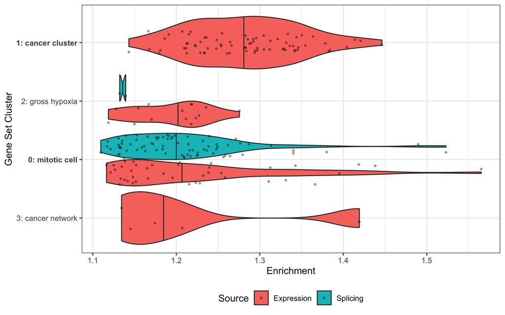

```r
plotViolin(
  geneSetsList = exampleGsList,
  highligthClusterNo = c(0,1),
  removeClusterId = FALSE
)
```

These plots are usefull for showing differences in regulation (one cluster being up regulated while another is down regulated).

We can investigate how the clusters relate to one another using the per-cluster average deprogram:

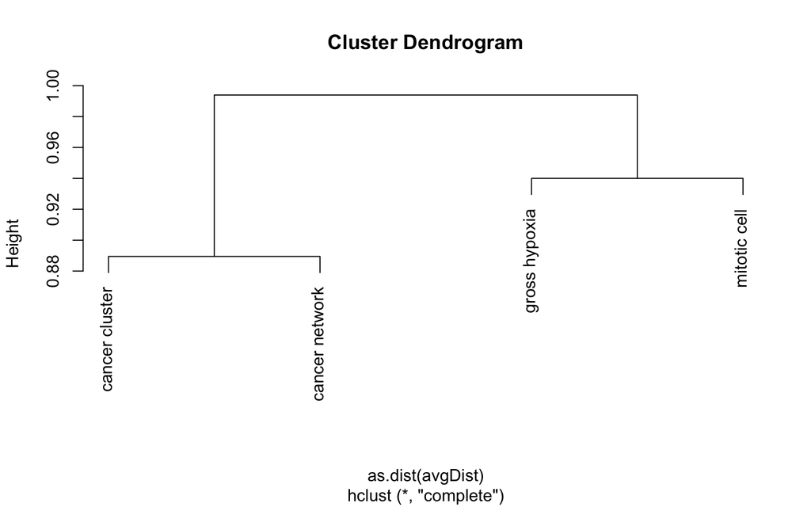

```r
plotDendogram(
  geneSetsList = exampleGsList,
  removeClusterId = TRUE
)
```

## Exploring and verifying clusters

The most important thing to get correct is the clustering “level” controlled by the `resolution` argument (as shown above in the Cluster and label gene-sets section). This parameter is automatically tuned by `geneSetSimplifyR` but we still always recommend visualizing how different cluster resolution affect the clusters via the [clustree R package](https://cran.r-project.org/web/packages/clustree/index.html) here wrapped in the *plotClustree()* function:

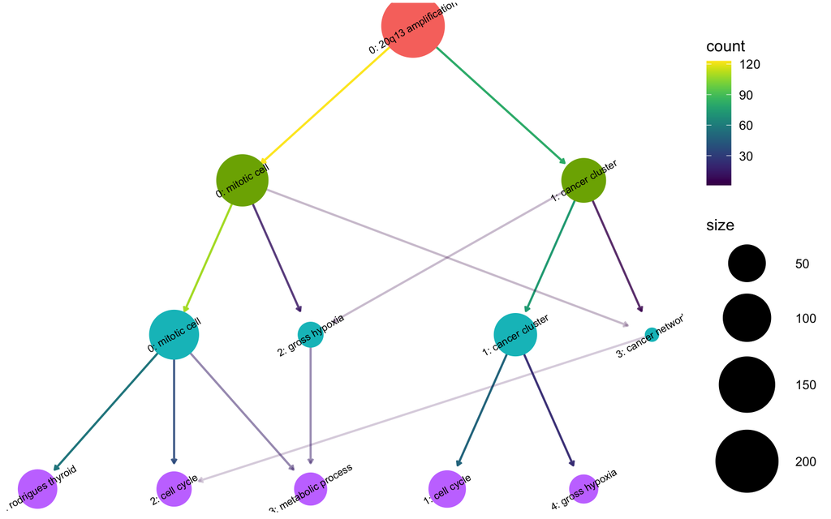

```r
plotClustree(exampleGsList)
```

This is a very powerful way to see how the gene-sets are distributed into different clusters and for helping with verifying the clustering “level”, as determined by the resolution, is correct.

This can naturally be followed up by e.g. a UMAP of a different resolution - here of the 1.6:

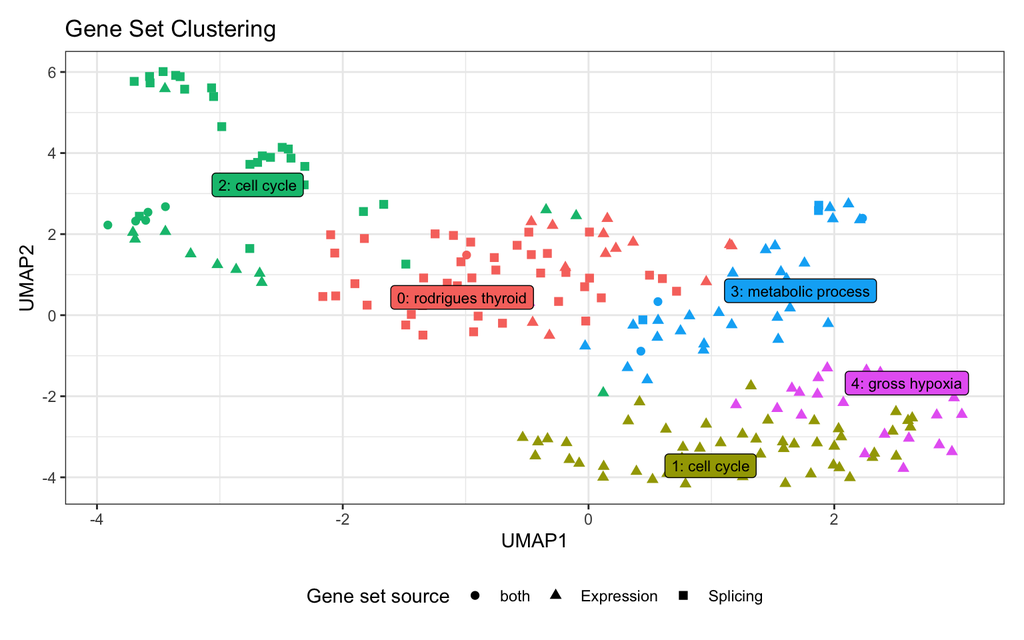

```r
plotUMAP(
  geneSetsList = exampleGsList,
  resolution = 1.6,
  pointAlpha = 1 # because there are relatively few gene-sets here
)
```

Please note the `resolution` paramter is also implemented for all plotting functions.

In this case we might determine this resolution better fit our data. Lets update the default resolution

```r
exampleGsList <- updateResolution(
  geneSetsList = exampleGsList,
  resolution = 1.6
)

exampleGsList
```

```
#> [1] "A gsList object with 204 gene sets from 2 source(s) clustered into 5 labeled clusters."
```

Once we have verified the cluster resolution is suitable (for your analysis) we can continue to verifying the cluster labels. While we spend a lot of time optimizing the approach `geneSetSimplifyR` uses to extract informative labels for each cluster it is not a perfect process. Therefore we have build functionality to both explore and change cluster labels.

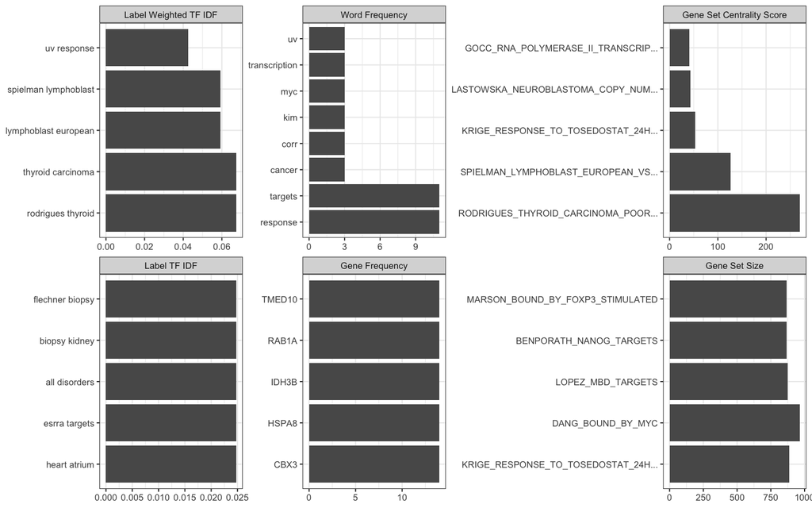

```r
plotClusterLabels(
  geneSetsList = exampleGsList,
  clusterNumber = 0,
  maxChar = 35 # shorten gene-set names to fit in vignette
) +
  theme_bw(base_size = 8) # make font smaller to fit in vignette
```

From which a LOT of summary info can be seen for this particular cluster:

- The label TF-IDF meaning the two-words that are most enriched in this cluster compared to other clusters (bottom left)
- The gene-sets most central in the KNN graph produced (top right)
- The weighted TF IDF - that is the TF IDF scores weighted by gene-set centrality. This is the one that defines the cluster label (top left).
- The most frequent words in the gene-set names (top mid)
- The most frequent genes in the gene-sets (bottom mid)
- The largest gene-sets in the cluster (bottom right)

We recommend that you always inspect the output from *plotClusterLabels()* for ALL your clusters to ensure the labeling are appropriate.

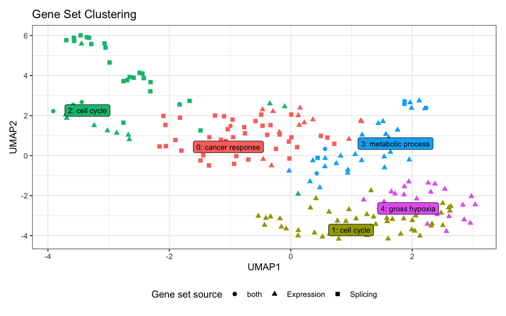

```r
exampleGsList <- updateClusterLabels(
  geneSetsList = exampleGsList,
  clusterNumber = 0,
  newClusterName = 'cancer response'
)

plotUMAP(
  geneSetsList = exampleGsList,
  pointAlpha = 1 # because there are relatively few gene-sets here
)
```

To verify the clustering you can naturally also look at all the gene-sets annotated to a cluster:

```r
gsTable <- extractTable(
  geneSetsList = exampleGsList,
  summarize = FALSE
)

head(gsTable)
```

```
#> # A tibble: 6 × 5
#>   source     pathway                                     enric…¹ cluster initi…²
#>   <chr>      <chr>                                         <dbl> <chr>   <chr>
#> 1 Splicing   BENPORATH_NANOG_TARGETS                        1.12 cancer… rodrig…
#> 2 Expression RODRIGUES_THYROID_CARCINOMA_POORLY_DIFFERE…    1.23 cancer… rodrig…
#> 3 Expression KRIGE_RESPONSE_TO_TOSEDOSTAT_24HR_DN           1.14 cancer… rodrig…
#> 4 Expression FLECHNER_BIOPSY_KIDNEY_TRANSPLANT_REJECTED…    1.17 cancer… rodrig…
#> 5 Expression KRIGE_RESPONSE_TO_TOSEDOSTAT_6HR_DN            1.12 cancer… rodrig…
#> 6 Expression KAAB_HEART_ATRIUM_VS_VENTRICLE_DN              1.20 cancer… rodrig…
#> # … with abbreviated variable names ¹enrichment_score, ²initial_cluster_label
```

We recommend this table to ALWAYS be add to the supplementary material of an article(!) as it is key to both transparency and reproducibility!

For reporting purpose this table can also be summarized:

```r
gsSummary <- extractTable(
  geneSetsList = exampleGsList,
  summarize = TRUE
)

head(gsSummary)
```

```
#> # A tibble: 6 × 5
#>   source     cluster           `enrichment mean` `enrichment sd` genesets
#>   <chr>      <chr>                         <dbl>           <dbl>    <int>
#> 1 Expression cancer response                1.21            0.09       15
#> 2 Splicing   cancer response                1.19            0.05       43
#> 3 Expression cell cycle                     1.3             0.06       49
#> 4 Expression cell cycle                     1.21            0.13       17
#> 5 Splicing   cell cycle                     1.23            0.1        29
#> 6 Expression metabolic process              1.22            0.07       31
```

## Extra details

### Plot modifications

All visualization functions returns a ggplot2 object:

```r
data("exampleGsList")

p1 <- plotBarchart(
  geneSetsList = exampleGsList,
  highligthClusterNo = c(0,1)
)
class(p1)
```

```
#> [1] "gg"     "ggplot"
```

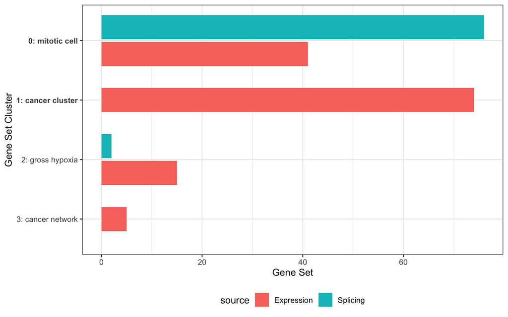

```r
p1
```

This also means all plots can easily be modified using standard ggplot2 operations:

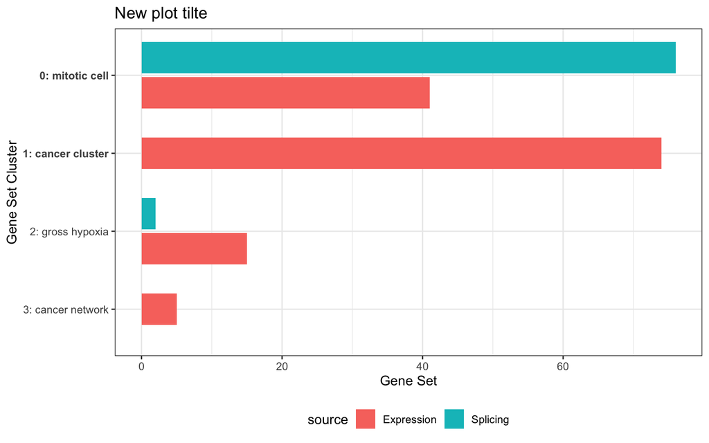

```r
p1 +
  ggtitle('New plot tilte')
```

Such ggplot2 operation are *really* easy to google since ggplot2 have millions of users. So if you want to modify any plot in some way just google that in conjunction with ggplot2 and you will find your answer (e.g. “ggplot2 change fill color”)

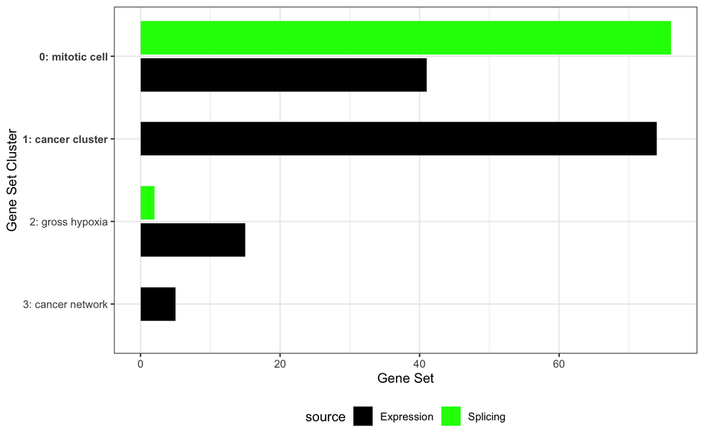

```r
p1 +
  scale_fill_manual(values = c('black','green'))
```

### geneSetSimplifyR under the hood

The *geneSetSimplifyR()* function is actually just a high-level function which itself calls 3 sub-functions:

1. *initializeList()* which create the initial gsList object
2. *clusterGeneSets()* which performs the clustering
3. *labelClusters()* which adds the labels

Each of these functions can naturally be called consecutively allowing more user control of how each step is done.

For a detailed description of each step please refer to the paper.

# How to do gene-set enrichment analysis

Lets look at how to produce the input for `geneSetSimplifyR` via the `fgsea` package package and it’s example data

```r
library(fgsea)
data(examplePathways)
data(exampleRanks)
```

And here are the genes of interest (e.g. significant genes) from the `fgsea` package:

```r
sigGenes <- tail(names(exampleRanks), 750)
head(sigGenes)
```

```
#> [1] "105352" "18476"  "380912" "20788"  "57875"  "56175"
```

Then we can run a simple over-representation analysis (ORA) using the `fgsea` package as follows:

```r
oraRes <- fora(
  pathways = examplePathways,
  genes    = sigGenes,
  universe = names(exampleRanks)
)
sum(oraRes$padj < 0.05)
```

```
#> [1] 59
```

Note that the universe is ONLY consist of genes that actually had a change to be in the set of interesting genes (e.g. all genes tested) NOT all known genes!

Next we subset to significant genesets and calculate the enrichment score as `geneSetSimplifyR` can also use these for visualization.

```r
n_genes <- length(sigGenes)
n_universe <- length(exampleRanks)


oraSig <-
  tibble::as_tibble(oraRes) %>%
  dplyr::filter(
    padj < 0.05
  ) %>%
  dplyr::mutate(
    enrichment_score = log2(
      (
        ( overlap / size       ) /
        ( n_genes / n_universe )
      ) + 0.06
    )
  )

nrow(oraSig)
```

```
#> [1] 59
```

```r
head(oraSig)
```

```
#> # A tibble: 6 × 7
#>   pathway                            pval     padj overlap  size overl…¹ enric…²
#>   <chr>                             <dbl>    <dbl>   <int> <int> <list>    <dbl>
#> 1 5990980_Cell_Cycle             2.69e-26 3.82e-23      84   369 <chr>      1.89
#> 2 5990979_Cell_Cycle,_Mitotic    2.33e-25 1.65e-22      76   317 <chr>      1.96
#> 3 5991851_Mitotic_Prometaphase   3.59e-21 1.70e-18      35    82 <chr>      2.78
#> 4 5992217_Resolution_of_Sister_… 1.32e-18 4.67e-16      31    74 <chr>      2.76
#> 5 5991454_M_Phase                1.10e-14 3.13e-12      42   173 <chr>      1.98
#> 6 5991757_RHO_GTPases_Activate_… 6.22e-14 1.47e-11      27    78 <chr>      2.49
#> # … with abbreviated variable names ¹overlapGenes, ²enrichment_score
```

In this toy data there are only 59 significant gene sets but that is because it an artificail dataset only meant to illustrate the workflow. As discussed in the introduction 1000+ significant gene sets are very common. But even thougth it is possible to manually consider 59 gene sets lets use `geneSetSimplifyR` to analyze them anyway. This could be done as follows but will not be done in this section of the vignette since it is covered above in the geneSetSimplifyR workflow

exampleGsList <- geneSetSimplifyR( geneSetsList = examplePathways, geneSetsDF = oraSig, verbose = FALSE )